# Workshop on Webscraping

January 25, 2019

## Outline

- What is webscraping?
- Webscraping using `rvest`
- Examples
  - IMDB show cast
  - Poli Sci faculty names and rank

## What is Webscraping?

- Extract data from websites
  - Tables
  - Links to other websites
  - Text

[figure not shown]

[figure not shown]

## Why Webscrape?

- Because copy-paste will take a million years
- Because it's fast
- Because you can automate it

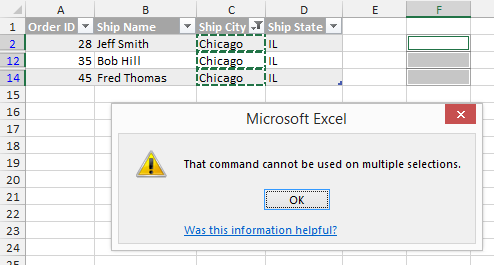

## Webscraping with `rvest`: Step-by-Step Start Guide

Install all tidyverse packages:

```r
# check if you already have it
library(tidyverse)
library(rvest)
# if not:
install.packages("tidyverse")
library(tidyverse) # only calls the "core" of tidyverse
```

## Step 1: What Website Are You Scraping?

```r
# character variable containing the url you want to scrape
myurl <- "https://www.imdb.com/title/tt7335184/"
```

## Step 2: Read HTML into R

- HTML is HyperText Markup Language.
- Go to any [website](https://www.imdb.com/title/tt7335184/), right click, click "View Page Source" to see the HTML

```r
library(tidyverse)
library(rvest)
myhtml <- read_html(myurl)
myhtml
```

```
## {xml_document}
## <html xmlns:og="http://ogp.me/ns#" xmlns:fb="http://www.facebook.com/2008/fbml">
## [1] <head>\n<meta http-equiv="Content-Type" content="text/html; charset= ...
## [2] <body id="styleguide-v2" class="fixed">\n\n            <img height=" ...
```

## Step 3: Where in the HTML Code Are Your Data?

Need to find your data within the `myhtml` object.

Tags to look for:

- `<p>` This is a paragraph.`</p>`
- `<h1>` This is a heading. `</h1>`
- `<a>` This is a link. `</a>`
- `<li>` item in a list `</li>`
- `<table>`This is a table. `</table>`

Can use [Selector Gadget](http://selectorgadget.com/) to find the exact location.

For more on HTML, check out the [W3schools' tutorial](http://www.w3schools.com/html/html_intro.asp) - You don't need to be an expert in HTML to webscrape with `rvest`!

## Step 4:

Give HTML tags into html_nodes() to extract your data of interest. Once you got the content of what you are looking for, use html_text to extract text, html_table to get a table

```r
mysummary<-html_nodes(myhtml, ".summary_text") #Gets everything in the element
mysummary
```

```
## {xml_nodeset (1)}
## [1] <div class="summary_text">\n                    A clever bookstore m ...
```

```r
html_text(mysummary)
```

```
## [1] "\n                    A clever bookstore manager relies on his savvy Internet know-how to make the woman of his dreams fall in love with him.\n            "
```

```r
#Or you can combine the operations into a pipe:
myhtml %>% html_nodes(".summary_text") %>% html_text()
```

```
## [1] "\n                    A clever bookstore manager relies on his savvy Internet know-how to make the woman of his dreams fall in love with him.\n            "
```

## Most Often, We Want to Extract a Table

```r
myhtml %>% html_nodes("table") %>% html_table(header = TRUE)
```

```
## [[1]]
##    Series cast summary: Series cast summary: Series cast summary:
## 1                    NA         Penn Badgley                  ...
## 2                    NA
## 3                    NA       Elizabeth Lail                  ...
## 4                    NA
## 5                    NA         Luca Padovan                  ...
## 6                    NA
## 7                    NA          Zach Cherry                  ...
## 8                    NA
## 9                    NA          Nicole Kang                  ...
## 10                   NA
## 11                   NA    Kathryn Gallagher                  ...
## 12                   NA
## 13                   NA      Daniel Cosgrove                  ...
## 14                   NA
## 15                   NA        Shay Mitchell                  ...
## 16                   NA
## 17                   NA   Victoria Cartagena                  ...
## 18                   NA
##                                            Series cast summary:
## 1        Joe Goldberg\n                  11 episodes, 2018-2019
## 2
## 3           Guinevere Beck\n                  10 episodes, 2018
## 4
## 5                     Paco\n                  10 episodes, 2018
## 6
## 7                    Ethan\n                  10 episodes, 2018
## 8
## 9   Lynn\n         / ...  \n                  10 episodes, 2018
## 10
## 11 Annika\n         / ...  \n                  8 episodes, 2018
## 12
## 13                      Ron\n                  7 episodes, 2018
## 14
## 15           Peach Salinger\n                  6 episodes, 2018
## 16
## 17                  Claudia\n                  5 episodes, 2018
## 18
##
## [[2]]
##                     Amazon Affiliates
## 1 Amazon VideoWatch Movies &TV Online
##                              Amazon Affiliates
## 1 Prime VideoUnlimited Streamingof Movies & TV
##                          Amazon Affiliates
## 1 Amazon GermanyBuy Movies onDVD & Blu-ray
##                        Amazon Affiliates
## 1 Amazon ItalyBuy Movies onDVD & Blu-ray
##                         Amazon Affiliates
## 1 Amazon FranceBuy Movies onDVD & Blu-ray
##                       Amazon Affiliates          Amazon Affiliates
## 1 Amazon IndiaBuy Movie andTV Show DVDs DPReviewDigitalPhotography
##            Amazon Affiliates
## 1 AudibleDownloadAudio Books
```

## Step 5: Save and Clean the Data

- Notice that there are actually two tables on this page
- You may want to remove all columns except Actor and Role.
- Here is some sample code to clean this, but there are many ways to do the same:

```r
library(stringr)
library(magrittr)
mydat <- myhtml %>%
  html_nodes("table") %>%
  extract2(1) %>%
  html_table(header = TRUE)
mydat <- mydat[,c(2,4)]
names(mydat) <- c("Actor", "Role")
mydat <- mydat %>%
  mutate(Actor = Actor,
         Role = str_extract(Role,"[^\\n]+"))
mydat = mydat[seq(1, nrow(mydat), 2), ]
mydat
```

```
##                 Actor           Role
## 1        Penn Badgley   Joe Goldberg
## 3      Elizabeth Lail Guinevere Beck
## 5        Luca Padovan           Paco
## 7         Zach Cherry          Ethan
## 9         Nicole Kang           Lynn
## 11  Kathryn Gallagher         Annika
## 13    Daniel Cosgrove            Ron
## 15      Shay Mitchell Peach Salinger
## 17 Victoria Cartagena        Claudia
```

## Your Turn:

- Follow the same steps to get the cast of the new Spider-man movie.

```r
myhtml <- read_html("https://www.imdb.com/title/tt4633694/?ref_=inth_ov_tt")
myhtml %>% html_nodes("table") %>% html_table(header = TRUE)
```

```
## [[1]]
##    Cast overview, first billed only: Cast overview, first billed only:
## 1                                 NA                     Shameik Moore
## 2                                 NA                      Jake Johnson
## 3                                 NA                  Hailee Steinfeld
## 4                                 NA                    Mahershala Ali
## 5                                 NA                 Brian Tyree Henry
## 6                                 NA                       Lily Tomlin
## 7                                 NA                 Luna Lauren Velez
## 8                                 NA                       Zoë Kravitz
## 9                                 NA                      John Mulaney
## 10                                NA                      Kimiko Glenn
## 11                                NA                      Nicolas Cage
## 12                                NA                      Kathryn Hahn
## 13                                NA                    Liev Schreiber
```

[output cut: 34 more lines]

```r
mydat <- myhtml %>%
  html_nodes("table") %>%
  extract2(1) %>%
  html_table(header = TRUE)
mydat <- mydat[,c(2,4)]
names(mydat) <- c("Actor", "Role")
mydat <- mydat %>%
  mutate(Actor = Actor,
         Role = str_extract(Role,"[^\\n]+"))
mydat = mydat[seq(1, nrow(mydat), 2), ]
mydat
```

```
##                Actor             Role
## 1      Shameik Moore   Miles Morales
## 3   Hailee Steinfeld      Gwen Stacy
## 5  Brian Tyree Henry Jefferson Davis
## 7  Luna Lauren Velez     Rio Morales
## 9       John Mulaney      Spider-Ham
## 11      Nicolas Cage Spider-Man Noir
## 13    Liev Schreiber     Wilson Fisk
## 15   Natalie Morales   Miss Calleros
```

## Example 2: Get Names and Ranks of Faculty:

- Step 1: need to get paths to all individual pages

```r
myhtml <- read_html("https://www.pols.iastate.edu/dir/#faculty")

facpaths<-html_nodes(myhtml, "a")[62:86] %>% html_attr("href")
urlstump<-"https://www.pols.iastate.edu"
mypaths<-paste0(urlstump, facpaths)
mypaths
```

```
##  [1] "https://www.pols.iastate.edu/directory/david-andersen/"
##  [2] "https://www.pols.iastate.edu/directory/olga-chyzh/"
##  [3] "https://www.pols.iastate.edu/directory/dirk-deam/"
##  [4] "https://www.pols.iastate.edu/directory/tessa-ditonto/"
##  [5] "https://www.pols.iastate.edu/directory/betty-dobratz/"
##  [6] "https://www.pols.iastate.edu/directory/scott-feinstein/"
##  [7] "https://www.pols.iastate.edu/directory/nell-gabiam/"
##  [8] "https://www.pols.iastate.edu/directory/jonathan-hassid/"
##  [9] "https://www.pols.iastate.edu/directory/mark-jackson/"
## [10] "https://www.pols.iastate.edu/directory/karen-kedrowski/"
## [11] "https://www.pols.iastate.edu/directory/richard-mansbach/"
## [12] "https://www.pols.iastate.edu/directory/james-mccormick/"
## [13] "https://www.pols.iastate.edu/directory/mark-nieman/"
## [14] "https://www.pols.iastate.edu/directory/kenneth-peters/"
## [15] "https://www.pols.iastate.edu/directory/david-peterson/"
## [16] "https://www.pols.iastate.edu/directory/ellen-pirro/"
## [17] "https://www.pols.iastate.edu/directory/yue-ren/"
## [18] "https://www.pols.iastate.edu/directory/steffen-schmidt/"
## [19] "https://www.pols.iastate.edu/directory/kelly-shaw/"
## [20] "https://www.pols.iastate.edu/directory/amy-erica-smith/"
## [21] "https://www.pols.iastate.edu/directory/alex-tuckness/"
## [22] "https://www.pols.iastate.edu/directory/robert-urbatsch/"
## [23] "https://www.pols.iastate.edu/directory/kathleen-waggoner/"
## [24] "https://www.pols.iastate.edu/directory/yu-wang/"
## [25] "https://www.pols.iastate.edu/directory/clark-wolf/"
```

## Example 2: Get Names and Ranks of Faculty:

- Step 2: write a series of commands that will scrape an individual faculty name and rank
- Notice that the relevant css selectors are `.entry-title` and `.title`

```r
#Get the name:
mypaths[1] %>% read_html() %>%
      html_nodes(".entry-title") %>%
      html_text() -> pname

#Get the rank:
mypaths[1] %>% read_html() %>%
      html_nodes(".title") %>%
      html_text() -> title

#Put them together:
cbind.data.frame(name=unlist(pname),title=unlist(title))
```

```
##             name                       title
## 1 David Andersen Assistant Professor [POL S]
```

## Example 2: Get Names and Ranks of Faculty:

- Step 3: write a wrapper function that will do this for any faculty once given a url

```r
get_info<-function(myurl) {
  test <- try(myurl %>% read_html(), silent=T)
  if ("try-error" %in% class(test)) {
    return(NA)
  } else
    myurl %>% read_html() %>%
      html_nodes(".entry-title") %>%
      html_text() -> pname
    myurl %>% read_html() %>%
      html_nodes(".title") %>%
      html_text() -> title

    return(cbind.data.frame(name=unlist(pname),title=unlist(title)))
}

get_info(mypaths[1]) #Test the function
```

```
##             name                       title
## 1 David Andersen Assistant Professor [POL S]
```

```r
mydata<-do.call(rbind, lapply(mypaths, get_info))
mydata
```

```
##                 name                               title
## 1     David Andersen         Assistant Professor [POL S]
## 2         Olga Chyzh         Assistant Professor [POL S]
## 3          Dirk Deam             Senior Lecturer [POL S]
## 4      Tessa Ditonto         Assistant Professor [POL S]
## 5      Betty Dobratz                   Professor [SOC S]
## 6    Scott Feinstein         Assistant Professor [POL S]
## 7        Nell Gabiam           Associate Professor [WLC]
## 8    Jonathan Hassid         Associate Professor [POL S]
## 9       Mark Jackson
## 10   Karen Kedrowski                     Director [CCCC]
## 11  Richard Mansbach                   Professor [POL S]
## 12   James McCormick                   Professor [POL S]
## 13       Mark Nieman         Assistant Professor [POL S]
## 14    Kenneth Peters
## 15    David Peterson                   Professor [POL S]
## 16       Ellen Pirro             Senior Lecturer [POL S]
## 17           Yue Ren Adjunct Associate Professor [POL S]
## 18   Steffen Schmidt        University Professor [POL S]
## 19        Kelly Shaw             Senior Lecturer [POL S]
## 20   Amy Erica Smith         Assistant Professor [POL S]
## 21     Alex Tuckness                   Professor [POL S]
## 22   Robert Urbatsch
## 23 Kathleen Waggoner
## 24           Yu Wang         Assistant Professor [POL S]
## 25        Clark Wolf                   Professor [PH RS]
```

## Key Functions: `html_nodes`

- `html_nodes(x, "path")` extracts all elements from the page `x` that have the tag / class / id `path`. (Use SelectorGadget to determine `path`.)
- `html_node()` does the same thing but only returns the first matching element.
- Can be chained

```r
myhtml %>%
  html_nodes("p") %>% # first get all the paragraphs
  html_nodes("a") # then get all the links in those paragraphs
```

## Key Functions: `html_text`

- `html_text(x)` extracts all text from the nodeset `x`
- Good for cleaning output

```r
myhtml %>%
  html_nodes("p") %>% # first get all the paragraphs
  html_nodes("a") %>% # then get all the links in those paragraphs
  html_text() # get the linked text only
```

## Key Functions: `html_table`

- `html_table(x, header, fill)` - parse html table(s) from `x` into a data frame or list of data frames
- Structure of HTML makes finding and extracting tables easy!

```r
myhtml %>%
  html_nodes("table") %>% # get the tables
  head(2) # look at first 2
```

```r
myhtml %>%
  html_nodes("table") %>% # get the tables
  extract2(2) %>% # pick the second one to parse
  html_table(header = TRUE) # parse table
```

## Key functions: `html_attrs`

- `html_attrs(x)` - extracts all attribute elements from a nodeset `x`
- `html_attr(x, name)` - extracts the `name` attribute from all elements in nodeset `x`
- Attributes are things in the HTML like `href`, `title`, `class`, `style`, etc.
- Use these functions to find and extract your data

```r
myhtml %>%
  html_nodes("table") %>% extract2(2) %>%
  html_attrs()
```

```r
myhtml %>%
  html_nodes("p") %>% html_nodes("a") %>%
  html_attr("href")
```

## Other functions

- `html_children` - list the "children" of the HTML page. Can be chained like `html_nodes`
- `html_name` - gives the tags of a nodeset. Use in a chain with `html_children`

```r
myhtml %>%
  html_children() %>%
  html_name()
```

- `html_form` - parses HTML forms (checkboxes, fill-in-the-blanks, etc.)
- `html_session` - simulate a session in an html browser; use the functions `jump_to`, `back` to navigate through the page